# **Analysis of NBA data from 2000 to 2018**

# **Introduction**

### Statistical analysis is becoming more and more important in many sports including basketball. Teams are organizing analytics teams in their organization and makes many in-game and off-the-court decisions based on the data provided. This project is an attempt to visualize the analytics being used in the NBA and to derive interesting relationships between variables that are in the game of basketball.

### One big difference between the current NBA and the NBA of Michael Jordan's time is the use of the 3-point shot. Since the appearence of Stephen Curry in the NBA in 2009, the use of the 3-point shot has increased significantly. With NBA teams changing offensive tactics to be more focused on the 3-point shot, we make the assumption that the 3-point shot has become more important in winning a NBA game than before. The sections below will build up to figure out if the previous statement holds true to a certain degree.

### This article in this [link](https://www.cbssports.com/nba/news/how-stephen-curry-ushered-nbas-greatest-shooting-era-and-changed-the-perception-of-championship-teams/) explains the impact of Stephen Curry and how the 3-point shot has changed the NBA.

# **Data Collection**

### We will be gathering two datasets.

- League average stats from 2000-2018 in each year.
- NBA team average stats from 2000-2018 in each year

### For the first dataset, we will be web-scraping with the help of the urllib and BeautifulSoup. Prior Knowledge is expected. This dataset will be used during the visualization sections of the project. [Link to website](https://www.basketball-reference.com/leagues/NBA_stats_per_game.html)

### We want to gather information about the 3-point shot and the 2-point shot. Since the data from the selected website does contain stats related to the 2-point shot, we will calculated them with the following formulas.

1. 2PA = FGA - 3PA
2. 2PM = FGM - 3PM
3. 2P% = 2PM/2PA

Abbreviations ->

```
             3PA = 3-point shot attempts
             3PM = Made 3-point shots
             3P% = Made 3-point shot percentage(3PM/3PA)
             2PA = 2-point shot attempts
             2PM = Made 2-point shots
             2P% = Made 2-point shot percentage(2PM/2PA)
             FGA = Field Goal attempts
             FGM - Made Field Goals
             FG% = Made field goals percentage(FGM/FGA)
```

```python
from bs4 import BeautifulSoup
import pandas
import  numpy as np
import datetime
import requests
from urllib.request import urlopen, Request
import re
import matplotlib.pyplot as plt
from sklearn import linear_model
```

```python
hdr = {'User-Agent': 'Safari/13.1'}
r = Request('https://www.basketball-reference.com/leagues/NBA_stats_per_game.html', headers=hdr)

resp = urlopen(r)

respData = resp.read()

data = BeautifulSoup(respData)

table = data.find(id="stats")
table = table.find("tbody")
rows = table.find_all("tr")

years = []
three_points_attempt = []
year = 2019
three_points_made = []
three_points_percentage = []
two_points_attempt = []
two_points_made = []
two_points_percentage = []
for x in range(1,22):
  cols = rows[x].find_all("td")
  if not cols:
    continue
  else:
    year = year-1
    years.append(year)
    attempts3 = str(cols[10].renderContents())
    attempts3 = float(attempts3[2:-1])
    three_points_attempt.append(attempts3)
    mades3 = str(cols[9].renderContents())
    mades3 = float(mades3[2:-1])
    three_points_made.append(mades3)
    percents3 = str(cols[23].renderContents())
    percents3 = float(percents3[2:-1])
    three_points_percentage.append(percents3)
    fga = str(cols[8].renderContents())
    fga  = float(fga[2:-1])
    fgm = str(cols[7].renderContents())
    fgm  = float(fgm[2:-1])
    attempts2 = fga-attempts3
    mades2 = fgm-mades3
    percents2 = mades2/attempts2
    two_points_attempt.append(attempts2)
    two_points_made.append(mades2)
    two_points_percentage.append(percents2)
leagueData = pandas.DataFrame()
leagueData ["SEASON"] = years
leagueData ["3PA"] = three_points_attempt
leagueData ["3PM"] = three_points_made
leagueData ["3P%"] =three_points_percentage
leagueData ["2PA"] = two_points_attempt
leagueData ["2PM"] = two_points_made
leagueData ["2P%"] =two_points_percentage
leagueData  = leagueData[::-1].reset_index(drop=True)
leagueData.head(10)
```

|  | SEASON | 3PA | 3PM | 3P% | 2PA | 2PM | 2P% |
| --- | --- | --- | --- | --- | --- | --- | --- |
| 0 | 2000 | 13.7 | 4.8 | 0.354 | 66.9 | 30.9 | 0.461883 |
| 1 | 2001 | 14.7 | 5.2 | 0.354 | 66.6 | 31.0 | 0.465465 |
| 2 | 2002 | 14.7 | 5.1 | 0.349 | 66.1 | 30.6 | 0.462935 |
| 3 | 2003 | 14.9 | 5.2 | 0.347 | 64.9 | 29.8 | 0.459168 |
| 4 | 2004 | 15.8 | 5.6 | 0.356 | 64.5 | 30.3 | 0.469767 |
| 5 | 2005 | 16.0 | 5.7 | 0.358 | 63.0 | 30.1 | 0.477778 |
| 6 | 2006 | 16.9 | 6.1 | 0.358 | 62.8 | 30.4 | 0.484076 |
| 7 | 2007 | 18.1 | 6.6 | 0.362 | 63.4 | 30.7 | 0.484227 |
| 8 | 2008 | 18.1 | 6.6 | 0.367 | 62.8 | 30.5 | 0.485669 |
| 9 | 2009 | 18.1 | 6.4 | 0.355 | 63.6 | 31.3 | 0.492138 |

### Here, we will get data from Kaggle. This dataset consists of NBA team stats from 2000 to 2018. This time we will look at stats per team for each seasons to look at the relationships betweeen win rate and components of the game. Here I've used the uploaded the csv file using a local file uploader native to google colab. To download your own copy of the data follow this [link](https://www.kaggle.com/mharvnek/nba-team-stats-00-to-18)

```python
from google.colab import files
uploaded = files.upload()
```

Upload widget is only available when the cell has been executed in the current browser session. Please rerun this cell to enable.

```
Saving nba_team_stats_00_to_18.csv to nba_team_stats_00_to_18 (1).csv
```

```python
import io
df = pandas.read_csv(io.BytesIO(uploaded['nba_team_stats_00_to_18.csv']))
```

```python
df.head(10)
```

|  | Unnamed: 0 | TEAM | GP | W | L | WIN% | MIN | PTS | FGM | FGA | FG% | 3PM | 3PA | 3P% | FTM | FTA | FT% | OREB | DREB | REB | AST | TOV | STL | BLK | BLKA | PF | PFD | +/- | SEASON |
| --- | --- | --- | --- | --- | --- | --- | --- | --- | --- | --- | --- | --- | --- | --- | --- | --- | --- | --- | --- | --- | --- | --- | --- | --- | --- | --- | --- | --- | --- |
| 0 | 0 | Atlanta Hawks | 82 | 29 | 53 | 0.354 | 48.4 | 113.3 | 41.4 | 91.8 | 45.1 | 13.0 | 37.0 | 35.2 | 17.6 | 23.4 | 75.2 | 11.6 | 34.5 | 46.1 | 25.8 | 17.0 | 8.2 | 5.1 | 5.5 | 23.6 | 22.2 | -6.0 | 2018-19 |
| 1 | 1 | Boston Celtics | 82 | 49 | 33 | 0.598 | 48.2 | 112.4 | 42.1 | 90.5 | 46.5 | 12.6 | 34.5 | 36.5 | 15.6 | 19.5 | 80.2 | 9.8 | 34.7 | 44.5 | 26.3 | 12.8 | 8.6 | 5.3 | 3.9 | 20.4 | 19.5 | 4.4 | 2018-19 |
| 2 | 2 | Brooklyn Nets | 82 | 42 | 40 | 0.512 | 48.7 | 112.2 | 40.3 | 89.7 | 44.9 | 12.8 | 36.2 | 35.3 | 19.0 | 25.5 | 74.5 | 11.0 | 35.6 | 46.6 | 23.8 | 15.1 | 6.6 | 4.1 | 5.3 | 21.5 | 22.0 | -0.1 | 2018-19 |
| 3 | 3 | Charlotte Hornets | 82 | 39 | 43 | 0.476 | 48.4 | 110.7 | 40.2 | 89.8 | 44.8 | 11.9 | 33.9 | 35.1 | 18.4 | 23.1 | 79.7 | 9.9 | 33.9 | 43.8 | 23.2 | 12.2 | 7.2 | 4.9 | 6.0 | 18.9 | 20.6 | -1.1 | 2018-19 |
| 4 | 4 | Chicago Bulls | 82 | 22 | 60 | 0.268 | 48.5 | 104.9 | 39.8 | 87.9 | 45.3 | 9.1 | 25.9 | 35.1 | 16.2 | 20.7 | 78.3 | 8.8 | 34.1 | 42.9 | 21.9 | 14.1 | 7.4 | 4.3 | 5.8 | 20.3 | 18.7 | -8.4 | 2018-19 |
| 5 | 5 | Cleveland Cavaliers | 82 | 19 | 63 | 0.232 | 48.2 | 104.5 | 38.9 | 87.6 | 44.4 | 10.3 | 29.1 | 35.5 | 16.4 | 20.7 | 79.2 | 10.7 | 31.9 | 42.7 | 20.7 | 13.5 | 6.5 | 2.4 | 5.6 | 20.0 | 19.4 | -9.6 | 2018-19 |
| 6 | 6 | Dallas Mavericks | 82 | 33 | 49 | 0.402 | 48.2 | 108.9 | 38.8 | 86.9 | 44.7 | 12.5 | 36.6 | 34.0 | 18.8 | 25.3 | 74.2 | 10.1 | 35.2 | 45.3 | 23.4 | 14.2 | 6.5 | 4.3 | 4.5 | 20.1 | 23.2 | -1.3 | 2018-19 |
| 7 | 7 | Denver Nuggets | 82 | 54 | 28 | 0.659 | 48.1 | 110.7 | 41.9 | 90.0 | 46.6 | 11.0 | 31.4 | 35.1 | 15.8 | 20.9 | 75.5 | 11.9 | 34.5 | 46.4 | 27.4 | 13.4 | 7.7 | 4.4 | 5.0 | 20.0 | 20.4 | 4.0 | 2018-19 |
| 8 | 8 | Detroit Pistons | 82 | 41 | 41 | 0.500 | 48.4 | 107.0 | 38.8 | 88.3 | 44.0 | 12.1 | 34.8 | 34.8 | 17.3 | 23.1 | 74.7 | 11.4 | 33.6 | 45.0 | 22.5 | 13.8 | 6.9 | 4.0 | 5.1 | 22.1 | 21.3 | -0.2 | 2018-19 |
| 9 | 9 | Golden State Warriors | 82 | 57 | 25 | 0.695 | 48.3 | 117.7 | 44.0 | 89.8 | 49.1 | 13.3 | 34.4 | 38.5 | 16.3 | 20.4 | 80.1 | 9.7 | 36.5 | 46.2 | 29.4 | 14.3 | 7.6 | 6.4 | 3.6 | 21.4 | 19.5 | 6.5 | 2018-19 |

# **Data Processing**

```python
cleanData=df.drop(columns=["GP","W","L","MIN","OREB","DREB","BLKA","PF","PFD","FT%","FTA","+/-","TOV","PTS","FTM","REB","AST","STL","BLK"])

newSeasons = []

for season in cleanData["SEASON"]:
  newSeason = season[:4]
  newSeasons.append(int(newSeason))

cleanData["SEASON"] = newSeasons
cleanData["2PM"] = cleanData["FGM"]-cleanData["3PM"]
cleanData["2PA"] = cleanData["FGA"]-cleanData["3PA"]
cleanData["2P%"] = cleanData["2PM"]/cleanData["2PA"]

cleanData = cleanData.drop(columns= ["FGM","FGA","FG%"])

col = cleanData.pop("SEASON")
cleanData.insert(0, col.name, col)
cleanData = cleanData.drop(columns="Unnamed: 0")
cleanData.head(10)
```

|  | SEASON | TEAM | WIN% | 3PM | 3PA | 3P% | 2PM | 2PA | 2P% |
| --- | --- | --- | --- | --- | --- | --- | --- | --- | --- |
| 0 | 2018 | Atlanta Hawks | 0.354 | 13.0 | 37.0 | 35.2 | 28.4 | 54.8 | 0.518248 |
| 1 | 2018 | Boston Celtics | 0.598 | 12.6 | 34.5 | 36.5 | 29.5 | 56.0 | 0.526786 |
| 2 | 2018 | Brooklyn Nets | 0.512 | 12.8 | 36.2 | 35.3 | 27.5 | 53.5 | 0.514019 |
| 3 | 2018 | Charlotte Hornets | 0.476 | 11.9 | 33.9 | 35.1 | 28.3 | 55.9 | 0.506261 |
| 4 | 2018 | Chicago Bulls | 0.268 | 9.1 | 25.9 | 35.1 | 30.7 | 62.0 | 0.495161 |
| 5 | 2018 | Cleveland Cavaliers | 0.232 | 10.3 | 29.1 | 35.5 | 28.6 | 58.5 | 0.488889 |
| 6 | 2018 | Dallas Mavericks | 0.402 | 12.5 | 36.6 | 34.0 | 26.3 | 50.3 | 0.522863 |
| 7 | 2018 | Denver Nuggets | 0.659 | 11.0 | 31.4 | 35.1 | 30.9 | 58.6 | 0.527304 |
| 8 | 2018 | Detroit Pistons | 0.500 | 12.1 | 34.8 | 34.8 | 26.7 | 53.5 | 0.499065 |
| 9 | 2018 | Golden State Warriors | 0.695 | 13.3 | 34.4 | 38.5 | 30.7 | 55.4 | 0.554152 |

### It was mentioned in the introduction of this report that it is commonly known fact to NBA fans that the game changed around the time Stephen Curry was drafted to the league. To explore more about this, we will divide the dataset to two parts, 2000-2008 and 2009-2018. Also we will reverse the order of each dataframe so that it is chronological.

```python
cleanData = cleanData[::-1].reset_index(drop=True)


midpoint = cleanData[cleanData.SEASON==2009].first_valid_index()

firstHalf = cleanData[0:midpoint]

secondHalf = cleanData[midpoint:]
```

```python
firstHalf.head(10)
```

[output not shown]

```python
secondHalf.head(10)
```

[output not shown]

# **Visualization**

### In this section we will visualize how the statistics we've gathered on the 3-point and 2-point shots has changed over time in the NBA. For this we will used our first dataset that we've webscraped.

### We will fix the "SEASON" variable as our x-axis and put other variables in the y-axis to see how these statistics changed over the NBA seasons.

```
<function matplotlib.pyplot.show>
```

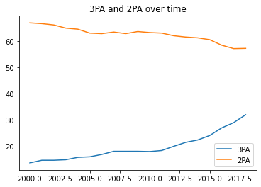

```python
plt.plot(leagueData["SEASON"],leagueData["3PA"],label ="3PA")
plt.plot(leagueData["SEASON"],leagueData["2PA"],label="2PA")
plt.title("3PA and 2PA over time")
plt.legend()
plt.show
```

```
<function matplotlib.pyplot.show>
```

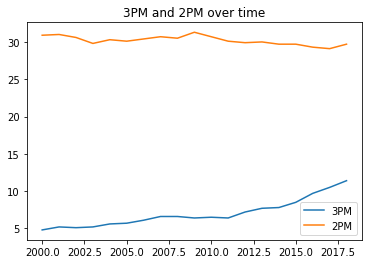

```python
plt.plot(leagueData["SEASON"],leagueData["3PM"],label ="3PM")
plt.plot(leagueData["SEASON"],leagueData["2PM"],label="2PM")
plt.title("3PM and 2PM over time")
plt.legend()
plt.show
```

```
<function matplotlib.pyplot.show>
```

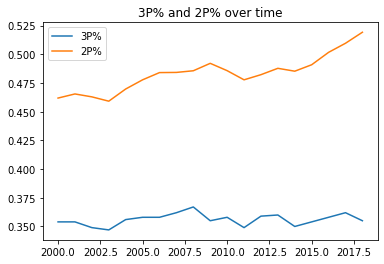

```python
plt.plot(leagueData["SEASON"],leagueData["3P%"],label ="3P%")
plt.plot(leagueData["SEASON"],leagueData["2P%"],label="2P%")
plt.title("3P% and 2P% over time")
plt.legend()
plt.show
```

### These points are aligned with the assumptions we made in the introduction - "The 3-point has become a more important factor in the NBA". The resulting plot of the 3P% statistic can be seem to contrast our hypothesis, but here we make a guess that the increased volume of 3-point shots contributed to the unpredicatble plot.

### Now that we've seen how the 3-point shot has become much more popular in the NBA, our next step is to figure if it really matters more in winning a game in the NBA. This will be explored in the Analysis step.

# **Analysis**

### In the analysis section of this project, we will use machine learning to find out the correlation between the 3,2 point shots and win rate in the NBA. A linear regression algorithem will be used to produce a predictive model which we will use to see if certain variables relating to the 3,2 point shots have a linear relationship with win rate. Here we will use the two datasets we've organized from Kaggle. By running linear regression on both the data from the "2000-2008" period and "2009-2018" period, we can see if winning basketball in the "Stephen Curry's 3-point shot era" really is related much with the 3-point shot.

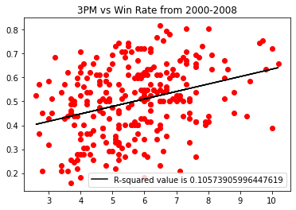

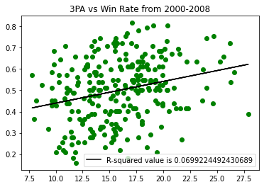

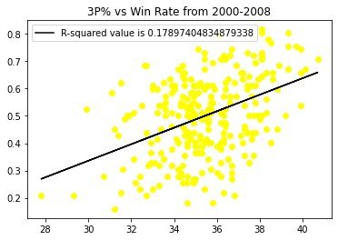

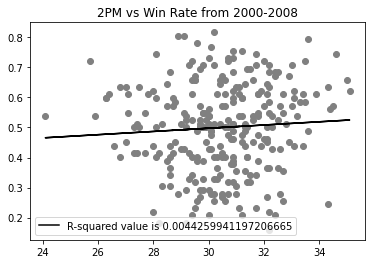

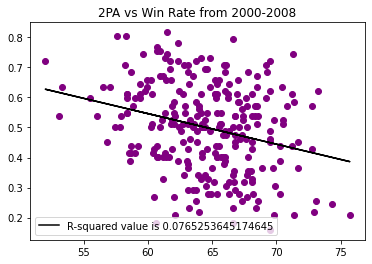

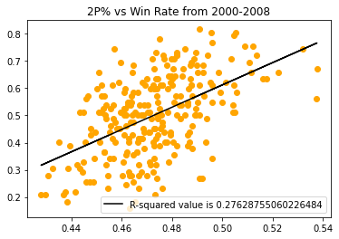

```python
winRates = [[y] for y in firstHalf['WIN%'].values]
colors = ["red" ,"green" ,"yellow","grey","purple","orange"]

for col in range(3,len(firstHalf.columns)):
  X = firstHalf[ firstHalf.columns[col]]
  plt.scatter(X, firstHalf['WIN%'],c=colors[col-3])
  regression = linear_model.LinearRegression()
  x = [[x] for x in X.values]
  regression.fit(x,winRates)
  prediction = regression.predict(x)
  r = regression.score(x,winRates)
  plt.plot(x,prediction, c='black', label="R-squared value is "+str(r))
  plt.legend()
  plt.title(firstHalf.columns[col]+" vs "+"Win Rate" " from 2000-2008")
  plt.show()
  plt.close()
```

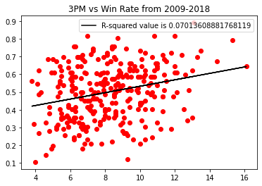

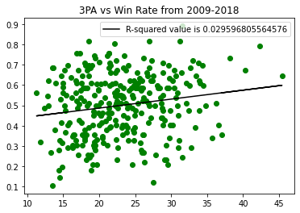

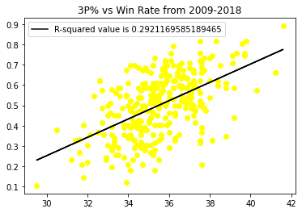

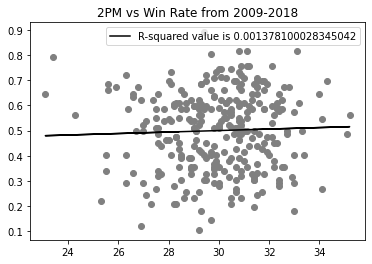

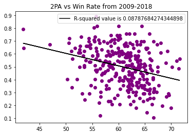

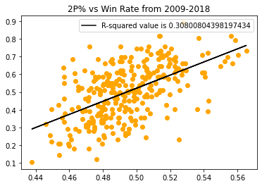

```python
winRates = [[y] for y in secondHalf['WIN%'].values]
colors = ["red" ,"green" ,"yellow","grey","purple","orange"]

for col in range(3,len(secondHalf.columns)):
  X = secondHalf[ secondHalf.columns[col]]
  plt.scatter(X, secondHalf['WIN%'],c=colors[col-3])
  regression = linear_model.LinearRegression()
  x = [[x] for x in X.values]
  regression.fit(x,winRates)
  prediction = regression.predict(x)
  r = regression.score(x,winRates)
  plt.plot(x,prediction, c='black', label="R-squared value is "+str(r))
  plt.legend()
  plt.title(secondHalf.columns[col]+" vs "+"Win Rate" +" from 2009-2018")
  plt.show()
  plt.close()
```

### Now lets analyze what these plots mean. The R-squared value evaluates how close the actual data are to the regression line. In general, a high R-squared value means a better model which means the x and y variables have a more linear relationship.

### Here are the R-squared values we've calculated rounded at the 3rd decimal place.

```
           2000-2008
```

- 3PM 0.106
- 3PA 0.07
- 3P% 0.179
- 2PM 0.004
- 2PA 0.077
- 2P% 0.276

  ```
       2009-2018
  ```

- 3PM 0.07
- 3PA 0.03
- 3P% 0.292
- 2PM 0.001
- 2PA 0.088
- 2P% 0.308

### All R-values are under 0.5 which means the x-variable has a very weak effect on the win rate. However, what we want to focus on is the difference between the R-squared values for the same x-variables between the two periods. Clearly, the biggest difference is seen in the 3P% vs Win% R-squared value as the 2009-2018 dataset's value is approximately 0.113 higher than then 2000-2008 dataset.

# **Insight**

### What have we learned from the series of processes starting from data collection to analysis using linear aggression? In the visualization step, we plotted series of [time vs 3,2 point shot data] graphs. Here we saw a reduce in popularity of the 2-point shot and an increase in popularity of the 3-point shot. Also, the accuracy of the 2-point shot increased and the accuracy of the 3-point shot has no outstanding trend. This can be explained by how NBA players do not take 2-point shots that are "long" or shot close to the 3-point line. This means more 2-point shots are attempted near the basketball which means a higher accuracy of the 2-point shot. This trend of avoiding the long 2-point shot is explained and visualized in this article. [link](https://www.r-bloggers.com/2018/04/assessing-shooting-performance-in-nba-and-ncaa-basketball/)

### Now what insight did we gain from the analysis step using linear regression? In this section we found that the highest difference in R-squared value occured with 3-point shot accuracy data. This can be translated to the statement ,"Out of the 6 variables(3pa, 3pm, 3p%, 2pa, 2pm, 2p%) the variable that has increased its influence on the win rate by most over time is 3-point shot accuracy." This statement aligns well with the earlier statement we made in the introduction of how the NBA has changed and how the 3-point shot became more important in winning.